# Lab 03 Activity Key

Author

Published

### Activity Objectives:

- Practice data visualization with the `tidyverse`
- Practice simulating data

### Instructions:

- Fill in the code chunks
- Render the Quarto document and submit both the `.qmd` and `.html` file on Canvas

## Activity

### 0) Check and set (if needed) your working directory. If you’d like to load packages with `library()`, please do so in this block.

```r
library(tidyverse)
```

## Simulation

### 1) Extend or modify the data simulation shown in class in some way. Feel free to choose something interesting to you, but some possible ideas are: adding an additional condition, modifying an existing condition, replacing some distributions with different ones, comparing distributions with different parameters (e.g., comparing different means, SDs, degrees of freedom, etc. within a distribution, like comparing a $\chi^2$ distribution with different degrees of freedom). For this extension, write 1–2 questions or goals below.

1. Compare how the CLT behaves with $\chi^2$ tests of different degrees of freedom.

### 2) Next, make your plan. This can be brief, but sketch out the steps you will take to program this. If your extension involves varying some parameters, distribution, etc., specify the different levels it will take (e.g., testing a $\chi^2$ distribution with degrees of freedom 1, 2, 3, and 4).

Replace existing distributions with $chi^2$ distributions of varying degrees of freedom, specifically df = 1, 2, 3, and 4.

### 3) Make your modifications to the simulation and show the results! Please include results for both the sample and sampling distributions.

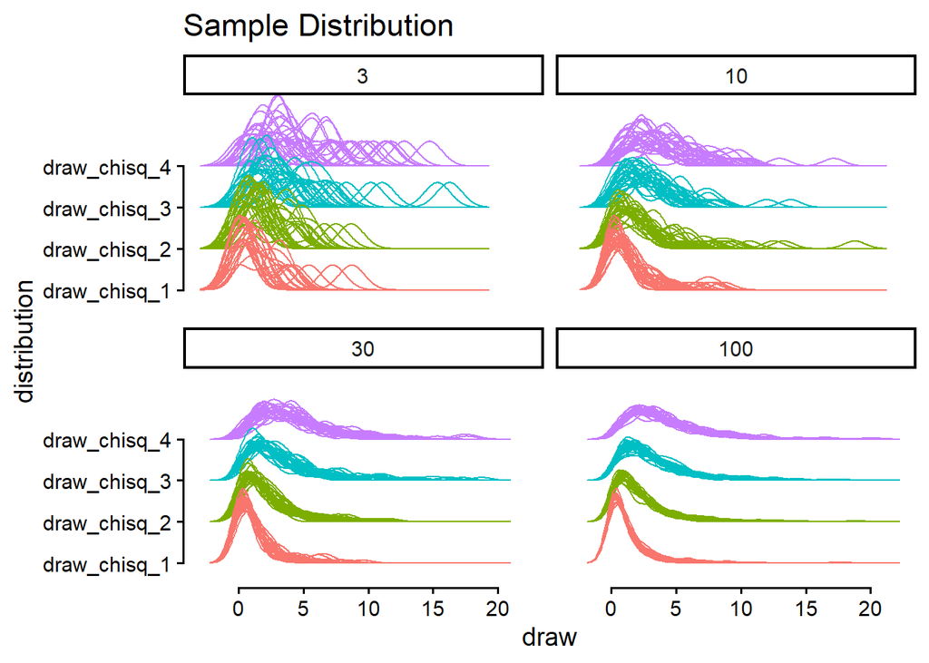

```r
n_reps <- 1000
sample_size <- c(3, 10, 30, 100)
total_n <- sum(n_reps * sample_size)

sim_data <- tibble(
  n_reps = n_reps,
  sample_size = sample_size
) |>
  uncount(n_reps, .id = "rep") |>
  uncount(sample_size, .id = "index", .remove = F) |>
  mutate(
    draw_chisq_1 = rchisq(total_n, df = 1),
    draw_chisq_2 = rchisq(total_n, df = 2),
    draw_chisq_3 = rchisq(total_n, df = 3),
    draw_chisq_4 = rchisq(total_n, df = 4)
  ) |>
  pivot_longer(starts_with("draw"),
               names_to = "distribution", values_to = "draw")

means <- sim_data |>
  summarize(.by = c(rep, distribution, sample_size),
            sample_mean = mean(draw))

sim_data |>
  filter(rep %in% sample(n_reps, size = 30)) |>
  ggplot(aes(x = draw, y = distribution,
             color = distribution, group = interaction(distribution, rep))) +
  ggridges::geom_density_ridges(alpha = 0.8, fill = NA) +
  theme_classic(base_size = 14) +
  guides(x = guide_axis(cap = T),
         y = guide_axis(cap = T),
         color = guide_none()) +
  facet_wrap(~ sample_size) +
  labs(title = "Sample Distribution")
```

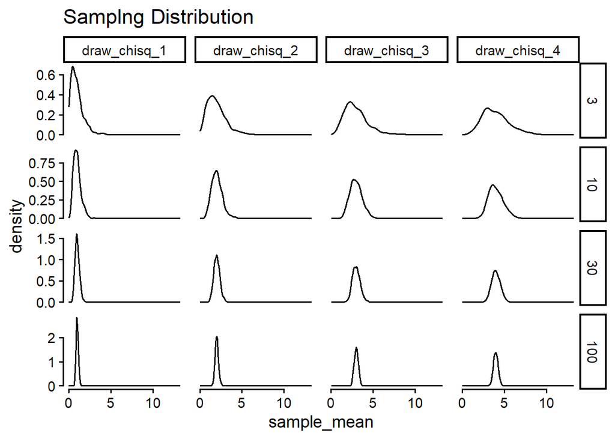

```r
means |>
  ggplot(aes(x = sample_mean)) +
  geom_density() +
  theme_classic(base_size = 14) +
  guides(x = guide_axis(cap = T),
         y = guide_axis(cap = T),
         color = guide_none()) +
  facet_grid(sample_size ~ distribution, scales = "free_y") +
  labs(title = "Samplng Distribution")
```

### 4) Provide a brief (2–4 sentences) writeup of your method and results.

# Whole Game Of Data Science

## Import

### 5) The `tidyverse` package includes a dataset called `billboard` that has song rankings for the Billboard Top 100 songs from the year 2000. You can access the `billboard` data object by just calling `billboard`. Use the `head()` function to display the first six rows. Then, use the `names()` to look at the column names.

```r
head(billboard)
```

```
# A tibble: 6 × 79
  artist      track date.entered   wk1   wk2   wk3   wk4   wk5   wk6   wk7   wk8
  <chr>       <chr> <date>       <dbl> <dbl> <dbl> <dbl> <dbl> <dbl> <dbl> <dbl>
1 2 Pac       Baby… 2000-02-26      87    82    72    77    87    94    99    NA
2 2Ge+her     The … 2000-09-02      91    87    92    NA    NA    NA    NA    NA
3 3 Doors Do… Kryp… 2000-04-08      81    70    68    67    66    57    54    53
4 3 Doors Do… Loser 2000-10-21      76    76    72    69    67    65    55    59
5 504 Boyz    Wobb… 2000-04-15      57    34    25    17    17    31    36    49
6 98^0        Give… 2000-08-19      51    39    34    26    26    19     2     2
# ℹ 68 more variables: wk9 <dbl>, wk10 <dbl>, wk11 <dbl>, wk12 <dbl>,
#   wk13 <dbl>, wk14 <dbl>, wk15 <dbl>, wk16 <dbl>, wk17 <dbl>, wk18 <dbl>,
#   wk19 <dbl>, wk20 <dbl>, wk21 <dbl>, wk22 <dbl>, wk23 <dbl>, wk24 <dbl>,
#   wk25 <dbl>, wk26 <dbl>, wk27 <dbl>, wk28 <dbl>, wk29 <dbl>, wk30 <dbl>,
#   wk31 <dbl>, wk32 <dbl>, wk33 <dbl>, wk34 <dbl>, wk35 <dbl>, wk36 <dbl>,
#   wk37 <dbl>, wk38 <dbl>, wk39 <dbl>, wk40 <dbl>, wk41 <dbl>, wk42 <dbl>,
#   wk43 <dbl>, wk44 <dbl>, wk45 <dbl>, wk46 <dbl>, wk47 <dbl>, wk48 <dbl>, …
```

```r
names(billboard)
```

```
 [1] "artist"       "track"        "date.entered" "wk1"          "wk2"
 [6] "wk3"          "wk4"          "wk5"          "wk6"          "wk7"
[11] "wk8"          "wk9"          "wk10"         "wk11"         "wk12"
[16] "wk13"         "wk14"         "wk15"         "wk16"         "wk17"
[21] "wk18"         "wk19"         "wk20"         "wk21"         "wk22"
[26] "wk23"         "wk24"         "wk25"         "wk26"         "wk27"
[31] "wk28"         "wk29"         "wk30"         "wk31"         "wk32"
[36] "wk33"         "wk34"         "wk35"         "wk36"         "wk37"
[41] "wk38"         "wk39"         "wk40"         "wk41"         "wk42"
[46] "wk43"         "wk44"         "wk45"         "wk46"         "wk47"
[51] "wk48"         "wk49"         "wk50"         "wk51"         "wk52"
[56] "wk53"         "wk54"         "wk55"         "wk56"         "wk57"
[61] "wk58"         "wk59"         "wk60"         "wk61"         "wk62"
[66] "wk63"         "wk64"         "wk65"         "wk66"         "wk67"
[71] "wk68"         "wk69"         "wk70"         "wk71"         "wk72"
[76] "wk73"         "wk74"         "wk75"         "wk76"
```

## Tidy

### 6a) Is the `billboards` dataset in wide or long format? How can you tell?

Wide! An “observation” here is a ranking in a given week, but all the weeks are in columns. They don’t have to specifically mention that an observation is a ranking in a week, but just something like this.

### 6b) Using the `?` tool on the dataset and / or the output from #3, please describe the contents of this dataset (specificially, an overview of what you can find in the columns) (1–2 sentences).

```r
#?billboards
```

In this dataset, we can find the artist name, track name, date that the track entered, and rankings for 76 weeks starting in 2000.

### 7c) Given what you said in #4a, would you want to use the `pivot_longer()` or `pivot_wider()` function on this data?

`pivot_longer()`

### 8) Using a pipe, let’s do a few things:

- Tidy the data as you planned to in #4c,
- Mutate the column with the numbered weeks so that it’s just numeric (hint: the `parse_number()` function will extract numbers from a string. Feel free to review its documentation with `?`),
- Assign this tidied version to a variable so we can continue using it.

After the pipe, print the first six rows from this tidied version.

```r
billboard_l <- billboard |>
  pivot_longer(cols = starts_with("wk"),
               names_to = "week", values_to = "ranking") |>
  mutate(week = parse_number(week))
head(billboard_l)
```

```
# A tibble: 6 × 5
  artist track                   date.entered  week ranking
  <chr>  <chr>                   <date>       <dbl>   <dbl>
1 2 Pac  Baby Don't Cry (Keep... 2000-02-26       1      87
2 2 Pac  Baby Don't Cry (Keep... 2000-02-26       2      82
3 2 Pac  Baby Don't Cry (Keep... 2000-02-26       3      72
4 2 Pac  Baby Don't Cry (Keep... 2000-02-26       4      77
5 2 Pac  Baby Don't Cry (Keep... 2000-02-26       5      87
6 2 Pac  Baby Don't Cry (Keep... 2000-02-26       6      94
```

## Transform

### 9) Let’s answer some questions with this data! Our first question is: what song spent the most number of weeks in the Billboard top 10? Using a pipe and the tidied dataset from the previous question, let’s do a few things:

- Filter the data to just include 10 or lower in the `ranking` column
- Summarize by the song name to get the number of weeks. HINT: the `n()` function returns the number of rows in a `summarize(.by = group)` group.
- Arrange the data with from highest to lowest number of weeks in the top 10

What song spent the most number of weeks in the Billboard top 10?

```r
billboard_l |>
  filter(ranking <= 10) |>
  summarize(.by = track, n_weeks = n()) |>
  arrange(desc(n_weeks))
```

```
# A tibble: 53 × 2
   track                   n_weeks
   <chr>                     <int>
 1 Breathe                      19
 2 Everything You Want          19
 3 Kryptonite                   18
 4 With Arms Wide Open          18
 5 Maria, Maria                 18
 6 Independent Women Pa...      17
 7 My Love Is Your Love         17
 8 I Knew I Loved You           17
 9 Jumpin' Jumpin'              16
10 I Wanna Know                 16
# ℹ 43 more rows
```

### 10) Come up with one question you’d like to ask of the data through data transformation.

### 11) Using a pipe, transform the data to address your question.

## Visualize (Bonus!)

If you’d like more practice doing data visualization, here are some extra exercises. These will not count towards your grade, but I will provide feedback if you choose to do them for practice.

### B1) Let’s plot the billboards data. Let’s make a line graph that has time (week) on the x-axis and a song’s ranking on the y-axis. Start by using the `ggplot()` function to make a grid with axes (no geoms yet).

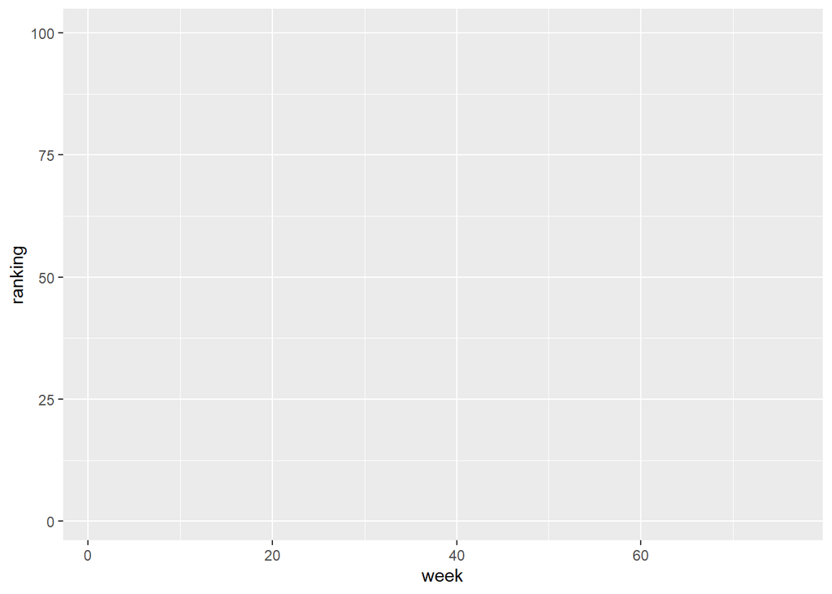

```r
billboard_l |>
  ggplot(aes(x = week, y = ranking))
```

### B2) Now, let’s add a `geom_line()` to show the rankings of the different songs over time. Remember you will need to add a `group` argument to your aes.

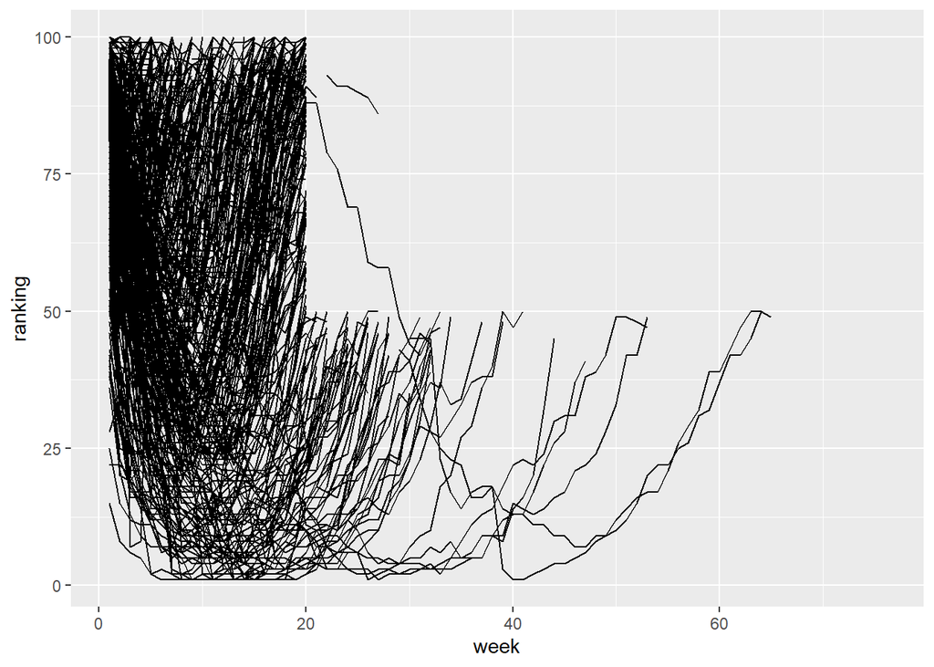

```r
billboard_l |>
  ggplot(aes(x = week, y = ranking, group = track)) +
  geom_line()
```

### B3) Because higher is “worse” for rankings, let’s reverse the y-axis so higher on the y is “better” by adding a scale layer. The function `scale_y_reverse()` will do this for us! Add it on to your plot just like you would add a new layer.

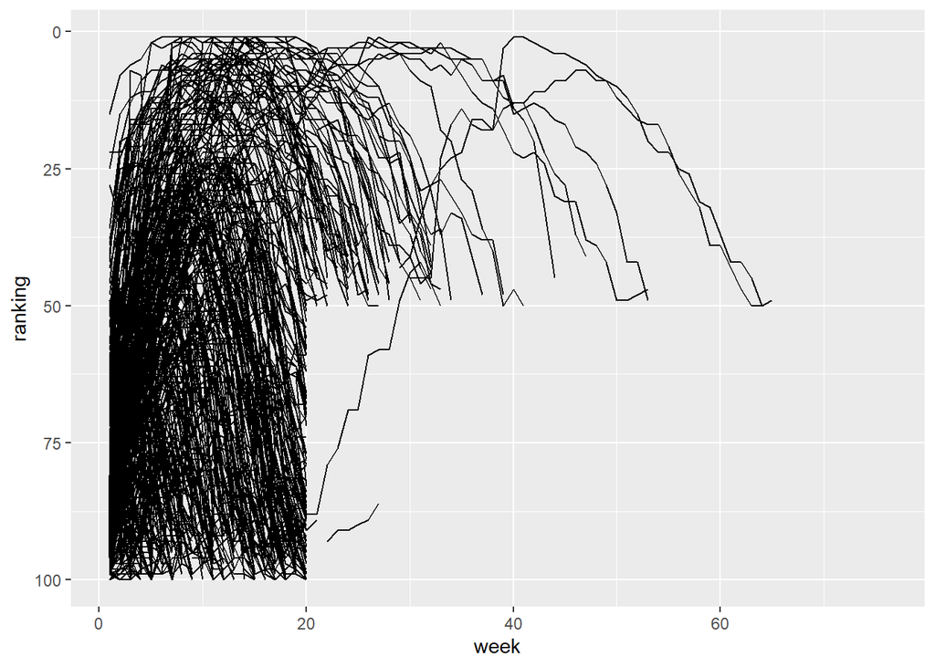

```r
billboard_l |>
  ggplot(aes(x = week, y = ranking, group = track)) +
  geom_line() +
  scale_y_reverse()
```

### B4) Modify the `alpha` argument within your geom to make it easier to see the patterns.

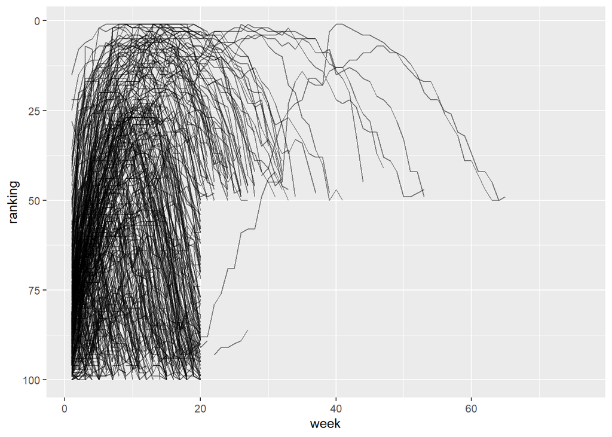

```r
billboard_l |>
  ggplot(aes(x = week, y = ranking, group = track)) +
  geom_line(alpha = .5) +
  scale_y_reverse()
```

### B6) Make three more modifications to this plot.

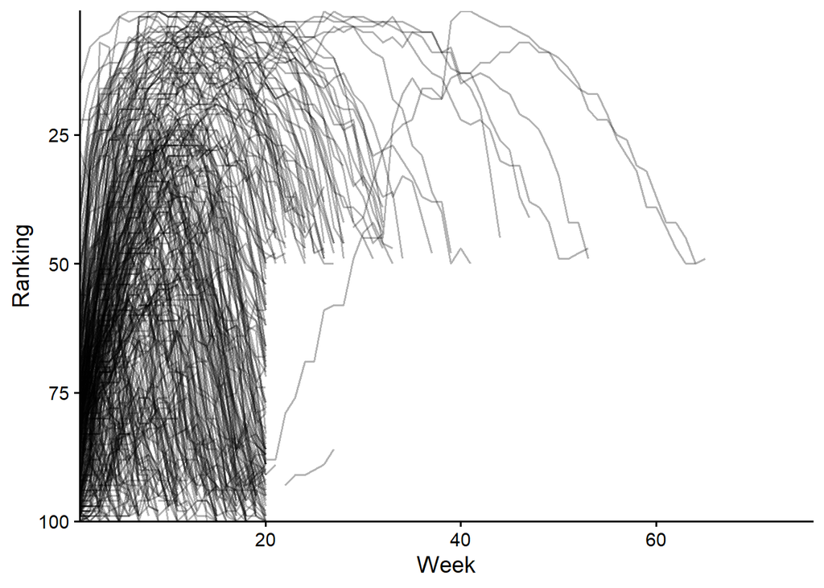

```r
billboard_l |>
  ggplot(aes(x = week, y = ranking, group = track)) +
  geom_line(alpha = .3) +
  scale_y_reverse() +
  coord_cartesian(expand = F) +
  labs(x = "Week", y = "Ranking") +
  theme_classic(base_size = 14)
```

### B7) Describe what you see in this plot (1–2 sentences).

Song rankings seem to increase and then fall soon after.